# In Class Assignment Three

In the following assignment you will be asked to fill in python code and derivations for a number of different problems. Please read all instructions carefully and turn in the rendered notebook (or HTML of the rendered notebook) before the end of class (or right after class). The initial portion of this notebook is given before class and the remainder is given during class. Please answer the initial questions before class, to the best of your ability. Once class has started you may rework your answers as a team for the initial part of the assignment.

## Contents

- Loading KDDCup Data
- The remaining links will be active for the in-class assignment:
- KDDCup Evaluation and Cross Validation
- More Cross Validation
- Statistical Comparison

**Before coming to class**, please make sure you have the latest version of `scikit-learn`. This notebook was created for version 0.18 and higher.

Back to Top

## Loading KDDCup Data

Please run the following code to read in the “KDD Cup” dataset from sklearn’s data loading module. It consists of examples of different simulated attacks for the 1998 DARPA Intrusion Detection System (IDS).

This will load the data into the variable `ds`. `ds` is a `bunch` object with fields like `ds.data` and `ds.target`. The field `ds.data` is a numpy matrix of the continuous features in the dataset. **The object is not a pandas dataframe. It is a numpy matrix.** Each row is a set of observed instances, each column is a different feature. It also has a field called `ds.target` that is an integer value we are trying to predict (i.e., a specific integer represents a specific person). Each entry in `ds.target` is a label for each row of the `ds.data` matrix.

```r
library(reticulate)
py_require("matplotlib")
py_require("numpy")
py_require("scikit-learn")
```

```python
# fetch the dataset
from sklearn.datasets import  fetch_kddcup99
from sklearn import __version__ as sklearn_version

print('Sklearn Version:',sklearn_version)
```

```
## Sklearn Version: 1.7.2
```

```python
ds = fetch_kddcup99(subset='http')
print(ds.data)
```

```
## [[-2.3025850929940455 5.199049364889368 8.60338923611281]
##  [-2.3025850929940455 5.476881874464279 6.1864143640514095]
##  [-2.3025850929940455 5.460010955546024 7.198258368620619]
##  ...
##  [-2.3025850929940455 5.313698468586339 7.090160165637395]
##  [-2.3025850929940455 5.6736668507515775 7.090160165637395]
##  [-2.3025850929940455 5.3895282466014205 7.118097238459137]]
```

```python
import numpy as np
# get some of the specifics of the dataset
X = ds.data
y = np.array(ds.target != b'normal.')
y = y.astype(int)

n_samples, n_features = X.shape
n_classes = len(np.unique(y))

print("n_samples: {}".format(n_samples))
```

```
## n_samples: 58725
```

```python
print("n_features: {}".format(n_features))
```

```
## n_features: 3
```

```python
print("n_classes: {}".format(n_classes))
```

```
## n_classes: 2
```

**Question 1:** How many instances are in the binary classification problem loaded above? How many instances are in each class? **Plot a pie chart or bar chart of the number of classes.**

```python
from matplotlib import pyplot as plt
plt.style.use('ggplot')

#=== Fill in code below========

arange = np.arange(n_classes).astype('str')
counts = np.bincount(y)

print('Number of instances in each class:', counts)
```

```
## Number of instances in each class: [56516  2209]
```

```python
plt.pie(counts, labels = arange)
```

```
## ([<matplotlib.patches.Wedge object at 0x164757980>, <matplotlib.patches.Wedge object at 0x16476e000>], [Text(-1.0923281031324767, 0.1296893022072589, '0'), Text(1.0923281453905571, -0.12968894628157832, '1')])
```

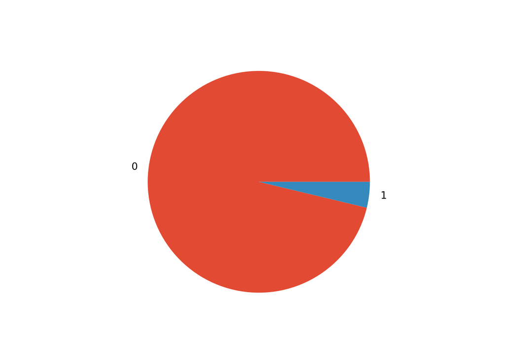

```python
plt.show()
```

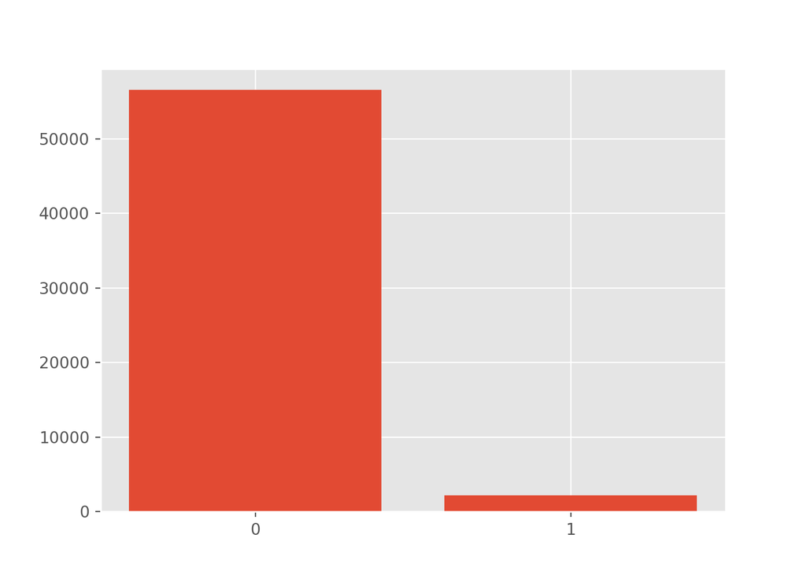

```python
plt.bar(arange, counts)
plt.show()
```

## Video notes

### Code sample imports

```python
from pprint import pprint
from sklearn.model_selection import train_test_split, \
    learning_curve, validation_curve, cross_val_score, GridSearchCV
from sklearn.preprocessing import StandardScaler
from sklearn.linear_model import LogisticRegression
from sklearn.decomposition import PCA
from sklearn.pipeline import Pipeline
from sklearn.metrics import classification_report

def plot_filled(train_scores,test_scores,train_x_axis, xlabel=''):
    train_mean = np.mean(train_scores, axis=1)
    train_std = np.std(train_scores, axis=1)
    test_mean = np.mean(test_scores, axis=1)
    test_std = np.std(test_scores, axis=1)

    plt.plot(train_x_axis, train_mean,
             color='blue', marker='o',
             markersize=5, label='training accuracy')

    plt.fill_between(train_x_axis,
                     train_mean + train_std,
                     train_mean - train_std,
                     alpha=0.15, color='blue')

    plt.plot(train_x_axis, test_mean,
             color='green', linestyle='--',
             marker='s', markersize=5,
             label='validation accuracy')

    plt.fill_between(train_x_axis,
                     test_mean + test_std,
                     test_mean - test_std,
                     alpha=0.15, color='green')

    plt.grid()
    plt.xlabel(xlabel)
    plt.ylabel('Accuracy')
    plt.legend(loc='lower right')
    plt.tight_layout()
```

### Pipeline overview (0:00-10:33)

- How reliable are our estimates of performance?
- Performance of a model may depend on other factors besides the learning algorithm:
  - Class distribution
  - Cost of misclassification
  - Size of training and test sets

Best practices:

- Combine pre- and post-processing into stages with pipelines
- Excellent way to prevent data snooping
  - Guarantees separation of testing and training sets
  - Example stages:
    - Scaling
    - Dimensionality Reduction
    - Learning Algorithm
    - Predictive Model

```python
X_train, X_test, y_train, y_test = train_test_split(X, y, test_size=0.20, random_state=1)

pipe_lr = Pipeline([('scl', StandardScaler()),
                    ('pca', PCA(n_components = 2)),
                    ('clf', LogisticRegression(random_state = 1))])

pipe_lr.fit(X_train, y_train)
```

```
Pipeline(steps=[('scl', StandardScaler()), ('pca', PCA(n_components=2)),
                ('clf', LogisticRegression(random_state=1))])
```

```python
print("Test Accuracy: %0.3f" % pipe_lr.score(X_test, y_test))
```

```
## Test Accuracy: 1.000
```

```python
y_pred = pipe_lr.predict(X_test)
```

Use a testing set, and *never, never, never* let the model see it. Strategies:

- Holdout
  - Reserve $x$% for training and $(1 - x)$% for testing
  - For instance, 80% for training and 20% for testing
  - Further split training into training and validation - useful for tuning hyperparameters without data snooping
  - Train, tune, and evaluate with training and validation sets
  - Final performance comes only from test set
- Random subsampling
  - Repeated holdout, with replacement
- Cross Validation (preferable to others in medium-size and smaller datasets)
  - Partition data into k disjoint subsets
  - $k$-fold: train on $k - 1$ partitions, test on the remaining one (often chosen to be 10 or sometimes 5, depending on size of dataset)
    - For instance, divide data into 10 folds, and for 10 iterations, choose a different fold to be the test fold
    - Then we can average the errors as well as get a variance of it
  - Leave-one-out: $k = M$ (usually too computationally intensive)
- Stratified Cross Validation
  - Select samples, keeping overall class distribution same for each fold
  - Same as k-fold but stratify folds by classes
  - We don’t want folds that are entirely the majority class!

### Time series analysis (10:34-18:06)

TL;DR: The primary point of performing cross validation on a dataset is **to understand how the algorithm might perform on data it was not trained with, as well as the variance in performance.** The secondary point is hyperparameter tuning: use the average performance from CV for the final model.

Therefore the situation must be a plausible deployment scenario, so that we have an idea of the hyperparameters and performance of using the entire dataset.

- Folds must be plausible, representative of the actual use case of a classifier.
- For instance, for time series data, you cannot apply stratified cross validation.
  - Points near each other in time might be very similar, solely due to how close their are in time, and not for predictive value.
  - In practice, you can’t interpolate between current and future points to obtain future data.
- Similarly, suppose we fold the data over time.
  - Although it’s not as bad as random stratification, we still end up with cross-validation cases where T1 < T2 < T3, and we use T1 and T3 to predict T2!
- Ideally, we take a fold of data, and predict the next point.
  - Then, add the next point and train on that, and so on!

### Intro to Learning Curve (18:07-25:00)

- How do we know a model is actually good?
  - We need to have low bias (accurate) *and* low variance (precise)
  - Complex models can really fit the training data, giving lower bias
  - Simpler models have trouble fitting data, resulting in higher bias
  - But complex models can have high variance in their decision!
- How do we estimate bias and variance for a classifier?
  - THe easiest way to do this is with a learning curve. If we train a lot of times, we can plot accuracy vs. sample size, as well as include a measure of spread for the accuracy.
  - You can’t estimate the curve without collecting the data. Some bounds are known but they are too loose to be useful.

### Learning Curve (25:00-27:08)

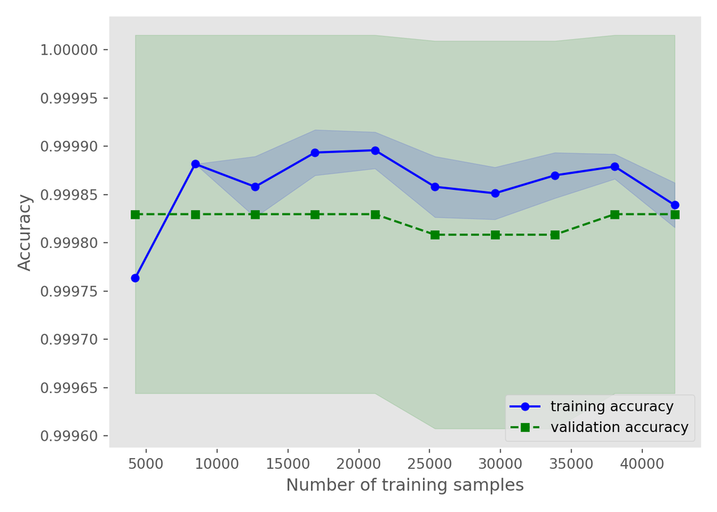

```python
pipe_lr = Pipeline([('scl', StandardScaler()),
                    ('pca', PCA(n_components = 2)),
                    ('clf', LogisticRegression(random_state = 0))])
train_sizes, train_scores, test_scores = learning_curve(
    estimator = pipe_lr, X = X_train, y = y_train,
    train_sizes = np.linspace(0.1, 1.0, 10),
    cv = 10, n_jobs = -1)

plot_filled(train_scores, test_scores, train_sizes,
    xlabel='Number of training samples')
plt.show()
```

### Validation Curve (27:08-)

```python
param_names = pipe_lr.get_params()
pprint(param_names)
```

```
## {'clf': LogisticRegression(random_state=0),
##  'clf__C': 1.0,
##  'clf__class_weight': None,
##  'clf__dual': False,
##  'clf__fit_intercept': True,
##  'clf__intercept_scaling': 1,
##  'clf__l1_ratio': None,
##  'clf__max_iter': 100,
##  'clf__multi_class': 'deprecated',
##  'clf__n_jobs': None,
##  'clf__penalty': 'l2',
##  'clf__random_state': 0,
##  'clf__solver': 'lbfgs',
##  'clf__tol': 0.0001,
##  'clf__verbose': 0,
##  'clf__warm_start': False,
##  'memory': None,
##  'pca': PCA(n_components=2),
##  'pca__copy': True,
##  'pca__iterated_power': 'auto',
##  'pca__n_components': 2,
##  'pca__n_oversamples': 10,
##  'pca__power_iteration_normalizer': 'auto',
##  'pca__random_state': None,
##  'pca__svd_solver': 'auto',
##  'pca__tol': 0.0,
##  'pca__whiten': False,
##  'scl': StandardScaler(),
##  'scl__copy': True,
##  'scl__with_mean': True,
##  'scl__with_std': True,
##  'steps': [('scl', StandardScaler()),
##            ('pca', PCA(n_components=2)),
##            ('clf', LogisticRegression(random_state=0))],
##  'transform_input': None,
##  'verbose': False}
```

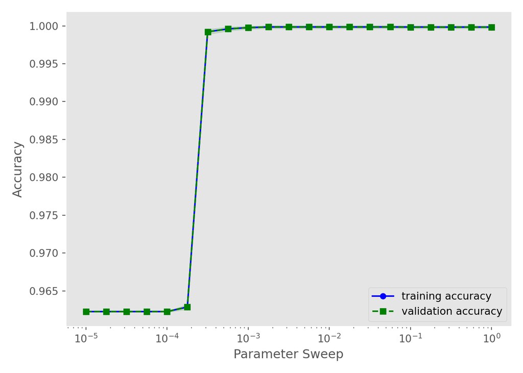

```python
param_range = np.logspace(-5, 0, 5 * 4 + 1)
train_scores, test_scores = validation_curve(
                estimator=pipe_lr,
                X=X_train,
                y=y_train,
                param_name='clf__C',
                param_range=param_range,
                cv=10, n_jobs=-1)
plot_filled(train_scores, test_scores, param_range, xlabel='Parameter Sweep')
plt.xscale('log')
plt.show()
```

Note: This is no longer a validation set as we have used it to tune the hyperparameters of the algorithm, thus we have potentially introduced data snooping.

This is why we want to divide into a training and validation fold, and we can select the best out of several tested parameters in a grid search. It’s called a grid search because we look at every pair of values.

```python
param_grid = {
    'pca__n_components': [1, 3],
    'clf__C': [0.00001, 0.0001, 0.001, 0.01, 0.1, 1.0,]
}
gs = GridSearchCV(estimator=pipe_lr,
    param_grid=param_grid,
    scoring='accuracy',
    cv = 2)

scores = cross_val_score(gs, X_train, y_train, scoring='accuracy', cv = 5)
print('CV accuracy: %0.3f \u00b1 %0.3f' % (np.mean(scores), np.std(scores)))
```

```
## CV accuracy: 1.000 ± 0.000
```